# Speakers in the Congressional Recored

## Parsed text

.txt files are saved on the Linstat server which you can access on your own computer as a [network drive](https://kb.wisc.edu/sscc/95802) or via the [Winstat VPN](https://kb.wisc.edu/sscc/working-from-home-or-other-remote-locations).

.txt file names look like this: “CREC-2010-11-16-pt1-PgH7478-000533-14413.txt”

They contain

- the date (“2010-11-16”)
- the page number (“pt1-PgH7478”–“H” because it is the House section, Senate is “S” and Extensions of Remarks is “E”)
- a speech ID assigned per day by the parser. “000533” means that this was the 533rd “speech” of the day (recall that “speeches” include simple speech acts like “I yield” as well as headers and other text that is not spoken parsed as seperate files)
- and finally, the members ICPSR ID. “14413” is Representative Norman Dicks.

[figure not shown]

```r
knitr::include_graphics(here("figs", "winstat.png"))
```

## Counts of total speeches

Because the parsed .txt files are saved in subfolders by year/icpsr, counts per member per year are just the number of files in each folder (see code/count_speeches.R)

```r
# from code/count_speeches.R
load(here('data', 'd_count.Rdata'))

# from voteview
load(here('data', 'members.Rdata'))

# join speech counts with voteview
d <- d_count %>% left_join(members)

d %<>% filter(year < 2021, chamber %in% c("House", "Senate"))

# name + district strings for display
d %<>% mutate(name_district = bioname %>% str_remove(",.*") %>% str_to_title() %>% paste(cqlabel)) %>%
  mutate(district_name = cqlabel %>% str_c(bioname, sep = ": ") %>% str_remove_all(",.*|\\(|\\)"))
```

### Most speeches per year

```r
d %>%
  select(year, name_district, icpsr, n_speeches) %>%
  arrange(-n_speeches) %>% kablebox()
```

| year | name_district | icpsr | n_speeches |
| --- | --- | --- | --- |
| 2009 | Mccain (AZ) | 15039 | 2953 |
| 2018 | Mcconnell (KY) | 14921 | 2718 |
| 2019 | Mcconnell (KY) | 14921 | 2645 |
| 2015 | Mcconnell (KY) | 14921 | 2460 |
| 2009 | Durbin (IL) | 15021 | 2189 |
| 2017 | Mcconnell (KY) | 14921 | 2143 |
| 2020 | Mcconnell (KY) | 14921 | 2101 |
| 2009 | Akin (MO-02) | 20123 | 1785 |
| 2007 | Durbin (IL) | 15021 | 1690 |
| 2016 | Mcconnell (KY) | 14921 | 1672 |
| 2007 | Kennedy (MA) | 10808 | 1586 |
| 2009 | Coburn (OK) | 29555 | 1512 |
| 2009 | Baucus (MT) | 14203 | 1457 |
| 2007 | Sessions (AL) | 49700 | 1367 |
| 2010 | Durbin (IL) | 15021 | 1225 |
| 2009 | Alexander (TN) | 40304 | 1129 |
| 2009 | Dodd (CT) | 14213 | 1128 |
| 2009 | Dorgan (ND) | 14812 | 1107 |
| 2009 | Poe (TX-02) | 20528 | 1084 |
| 2008 | Durbin (IL) | 15021 | 1077 |
| 2009 | Leahy (VT) | 14307 | 1035 |
| 2009 | Foxx (NC-05) | 20521 | 1011 |
| 2009 | Feinstein (CA) | 49300 | 1010 |
| 2011 | Levin (MI) | 14709 | 1000 |
| 2011 | Durbin (IL) | 15021 | 999 |
| 2007 | Levin (MI) | 14709 | 987 |
| 2013 | Durbin (IL) | 15021 | 984 |
| 2009 | Sessions (AL) | 49700 | 979 |
| 2007 | Harkin (IA) | 14230 | 978 |
| 2009 | Levin (MI) | 14709 | 974 |

[output cut: 70 more lines]

### The Wisconsin delegation

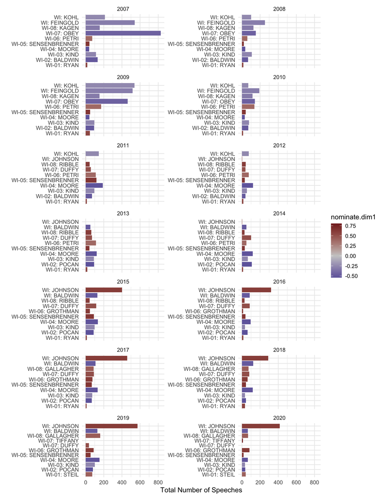

```r
d %>%
  filter(state_abbrev == "WI",!is.na(year)) %>%
  ggplot() +
  aes(x = n_speeches, y = district_name, fill = nominate.dim1) +
  geom_col() +
  facet_wrap("year", scales = "free_y", ncol = 2) +
  labs(y = "", x  = "Total Number of Speeches") +
  scale_fill_gradient2(low = muted("blue"), high = muted("red"), mid = "grey80")
```

### Average speeches per year for members of the House

```r
# as a table per member
d %>%
  filter(chamber == "House") %>%
  group_by(name_district) %>%
  summarise(average_speeches = mean(n_speeches) %>% round() ) %>%
  arrange(-average_speeches) %>%
  kablebox()
```

| name_district | average_speeches |
| --- | --- |
| Jackson (IL-02) | 671 |
| Young (IA-03) | 648 |
| Kucinich (OH-10) | 587 |
| Dreier (CA-26) | 560 |
| Jackson Lee (TX-18) | 528 |
| Poe (TX-02) | 510 |
| Akin (MO-02) | 483 |
| Oberstar (MN-08) | 476 |
| Conyers (MI-14) | 466 |
| Mcgovern (MA-02) | 438 |
| Hoyer (MD-05) | 406 |
| Mcgovern (MA-03) | 400 |
| Obey (WI-07) | 396 |
| Polis (CO-02) | 396 |
| Woolsey (CA-06) | 387 |
| Perlmutter (CO-07) | 377 |
| Garamendi (CA-10) | 370 |
| Filner (CA-51) | 365 |
| Maloney (NY-14) | 354 |
| Rangel (NY-15) | 354 |
| Skelton (MO-04) | 346 |
| Foxx (NC-05) | 341 |
| Miller (CA-07) | 339 |
| Towns (NY-10) | 325 |
| Slaughter (NY-28) | 319 |
| Engel (NY-16) | 318 |
| Royce (CA-39) | 316 |
| Connolly (VA-11) | 310 |
| Latham (IA-03) | 301 |
| Flake (AZ-06) | 299 |

[output cut: 70 more lines]

```r
# as a table per state
d %>%
  filter(chamber == "House") %>%
  group_by(state) %>%
  summarise(average_speeches = mean(n_speeches) %>% round() ) %>%
  kablebox()
```

| state | average_speeches |
| --- | --- |
| alabama | 75 |
| alaska | 22 |
| arizona | 104 |
| arkansas | 68 |
| california | 118 |
| colorado | 184 |
| connecticut | 108 |
| delaware | 80 |
| florida | 82 |
| georgia | 71 |
| hawaii | 87 |
| idaho | 79 |
| illinois | 104 |
| indiana | 91 |
| iowa | 120 |
| kansas | 60 |
| kentucky | 68 |
| louisiana | 69 |
| maine | 89 |
| maryland | 122 |
| massachusetts | 104 |
| michigan | 109 |
| minnesota | 131 |
| mississippi | 77 |
| missouri | 125 |
| montana | 88 |
| nebraska | 57 |
| nevada | 74 |
| new hampshire | 51 |
| new jersey | 119 |
| new mexico | 80 |
| new york | 110 |
| north carolina | 89 |
| north dakota | 62 |
| ohio | 89 |
| oklahoma | 62 |
| oregon | 143 |
| pennsylvania | 90 |
| rhode island | 125 |
| south carolina | 50 |
| south dakota | 50 |
| tennessee | 90 |
| texas | 119 |
| utah | 57 |
| vermont | 132 |
| virginia | 118 |
| washington | 77 |
| west virginia | 109 |
| wisconsin | 80 |
| wyoming | 100 |

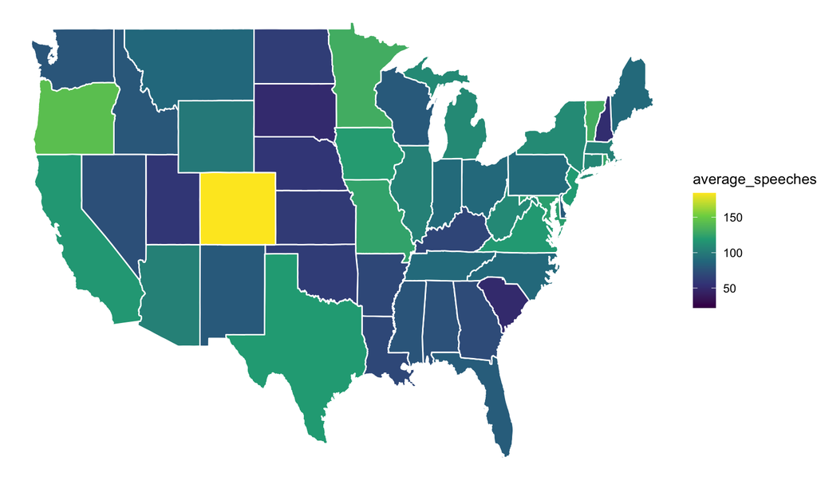

```r
# as a map
states <- map_data("state") %>% rename(state = region)

d %>%
  filter(chamber == "House") %>%
  group_by(state) %>%
  summarise(average_speeches = mean(n_speeches) ) %>%
  left_join(states) %>%
  group_by(subregion) %>%
  ggplot( aes(x = long, y = lat, group = group, fill = average_speeches) ) +
  geom_polygon(color = "white") +
  theme_void()
```

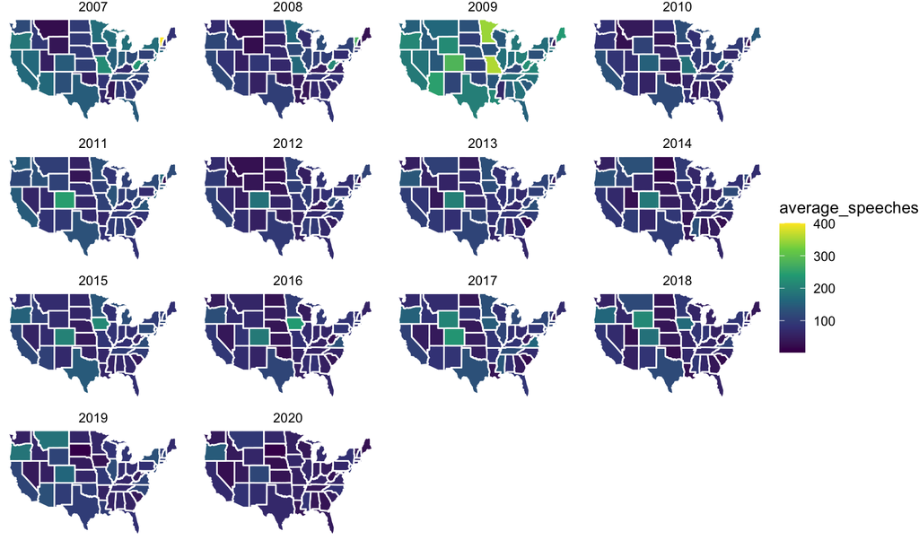

```r
d %>%
  filter(chamber == "House") %>%
  group_by(state, year) %>%
  summarise(average_speeches = mean(n_speeches) ) %>%
  left_join(states) %>%
  group_by(subregion) %>%
  ggplot( aes(x = long, y = lat, group = group, fill = average_speeches) ) +
  geom_polygon(color = "white") +
  theme_void() +
  facet_wrap("year")
```

## Counts of speeches by type

This is similar to counts of congressional record sections by type here, but now parsed by speaker. This means that “legislation” counts are much higher becasue each section of legislation contains many speakers.

### Types: legislation, business, process, and other

From `code/count_speeches.R`, saved as `data/d_meta.Rdata`

```
legislation_strings <- "ACT|BILL|RESOLUTION|AMENDMENT|EARMARK|APPROPRIATIONS|AUTHORIZATION|BUDGET|SPONSORS|WITHDRAWAL|PROVIDING FOR CONGRESSIONAL DISAPPROVAL OF A RULE SUBMITTED"

business_strings <- "PRAYER|PLEDGE OF ALLEGIANCE|MORNING BUSINESS|MESSAGE|PRIVILEGES OF THE|CONDEMING|APPOINTMENT|NOMINATION|CONFIRMATION|REPORT|PETITION|MEMORIAL|COMMUNICATION| MONTH|SCHEDULE|LEAVE OF ABSENCE|GENERAL LEAVE|ELECTING|RESIGNATION|MOMENT OF SILENCE"

process_strings <- "RECOGNIZED FOR [0-9] MINUTES|ANNOUNCEMENT|RESERVATION OF LEADER TIME|UNANIMOUS CONSENT|ADJOURNMENT|EXECUTIVE SESSION|PETITION| ORDER|^ORDER|MOTION|RECESS|CALENDAR|RECOGNITION|WELCOMING|OATH |SPEAKER PRO TEMPORE|MEASURES DISCHARGED|INTENT TO OBJECT"
```

```r
# clean up headers into type and subtype
load(here("data", "d_meta.Rdata"))

d_meta %>% count(type) %>% kablebox()
```

| type | n |
| --- | --- |
| business | 12422 |
| legislation | 207015 |
| other | 185391 |
| process | 18133 |

### Subtypes

```r
d_meta %>% count(type, subtype, sort = T) %>% kablebox()
```

| type | subtype | n |
| --- | --- | --- |
| legislation | ACT | 103327 |
| legislation | AMENDMENT | 28111 |
| legislation | APPROPRIATIONS | 26413 |
| legislation | AUTHORIZATION | 15651 |
| legislation | BILL | 14107 |
| legislation | RESOLUTION | 11850 |
| process | RECOGNITION | 6431 |
| process | EXECUTIVE SESSION | 5603 |
| other | NA | 5412 |
| legislation | BUDGET | 3889 |
| business | MONTH | 3483 |
| legislation | EARMARK | 2993 |
| business | NOMINATION | 2823 |
| business | REPORT | 2380 |
| other | ADDITIONAL STATEMENTS | 1963 |
| other | LEGISLATIVE PROGRAM | 1940 |
| other | HEALTH CARE REFORM | 1838 |
| process | CALENDAR | 1819 |
| process | MOTION | 1619 |
| other | PERSONAL EXPLANATION | 1599 |
| other | HEALTH CARE | 1516 |
| business | MEMORIAL | 1184 |
| other | LEGISLATIVE SESSION | 982 |
| process | WELCOMING | 740 |
| other | 30-SOMETHING WORKING GROUP | 736 |
| process | UNANIMOUS CONSENT | 681 |
| other | HONORING OUR ARMED FORCES | 618 |
| legislation | PROVIDING FOR CONGRESSIONAL DISAPPROVAL OF A RULE SUBMITTED | 529 |
| other | ENERGY | 458 |
| other | AUTHORITY FOR COMMITTEES TO MEET | 442 |

[output cut: 70 more lines]

### Type = “Other”

```r
count(d_meta %>% filter(type == "other"), subtype, sort = T) %>% kablebox()
```

| subtype | n |
| --- | --- |
| NA | 5412 |
| ADDITIONAL STATEMENTS | 1963 |
| LEGISLATIVE PROGRAM | 1940 |
| HEALTH CARE REFORM | 1838 |
| PERSONAL EXPLANATION | 1599 |
| HEALTH CARE | 1516 |
| LEGISLATIVE SESSION | 982 |
| 30-SOMETHING WORKING GROUP | 736 |
| HONORING OUR ARMED FORCES | 618 |
| ENERGY | 458 |
| AUTHORITY FOR COMMITTEES TO MEET | 442 |
| CLIMATE CHANGE | 381 |
| IRAQ | 379 |
| THE ECONOMY | 319 |
| OBAMACARE | 289 |
| IMMIGRATION | 276 |
| CONGRESSIONAL BLACK CAUCUS | 274 |
| RULES OF THE HOUSE | 266 |
| IMMIGRATION REFORM | 233 |
| MAKE IT IN AMERICA | 233 |
| DISAPPROVING A RULE SUBMITTED | 228 |
| NOTICES OF HEARINGS | 226 |
| ISSUES OF THE DAY | 217 |
| TRIAL OF DONALD J. TRUMP, PRESIDENT OF THE UNITED STATES | 214 |
| IDAHOANS SPEAK OUT ON HIGH ENERGY PRICES | 206 |
| IMPEACHING DONALD JOHN TRUMP, PRESIDENT OF THE UNITED STATES, FOR HIGH CRIMES AND MISDEMEANORS | 206 |
| CORONAVIRUS | 196 |
| ARMS SALES NOTIFICATION | 195 |
| SCHIP | 194 |
| TAX REFORM | 187 |

[output cut: 70 more lines]

## Counts of speeches mentioning district

The subset of speeches that mention “district” from `code/count_district.R` is saved as `data/d_district.Rdata`.

For more accurate and faster counts of district-oriented behavior etc., I am excluding two types of speeches:

- speeches under 1000 characters (always procedural, as far as I can tell)
- speeches that appear to be procedural or chamber business based their header text.

Average speeches per congress mentioning “district” from the Wisconsin delegation:

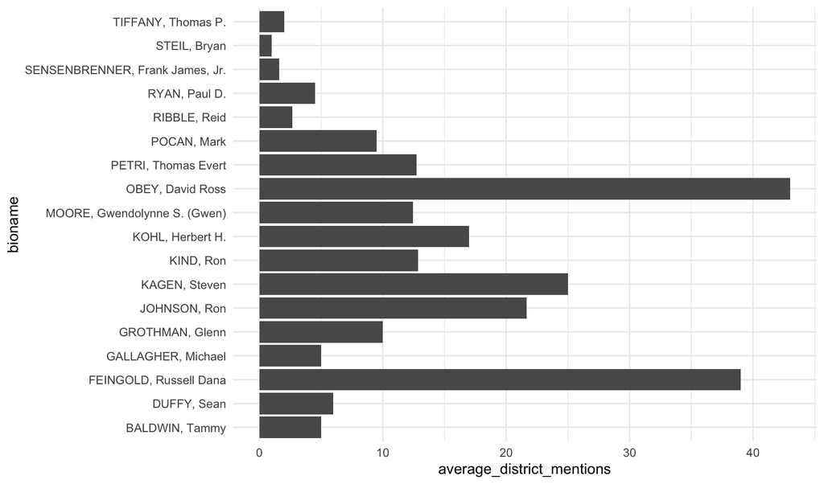

```r
load(here("data","d_district.Rdata"))

# average per member of the WI
d_district %>%
  filter(state_abbrev == "WI") %>%
  group_by(congress, icpsr, state_abbrev) %>%
  count(name = "district_mentions") %>%
  ungroup() %>%
  group_by(icpsr) %>%
  summarise(average_district_mentions = mean(district_mentions)) %>%
  left_join(members %>% distinct(bioname, icpsr)) %>%
  ggplot() +
  aes(x = average_district_mentions, y = bioname) +
  geom_col()
```

Average number speeches mentioning “district” for members of the House

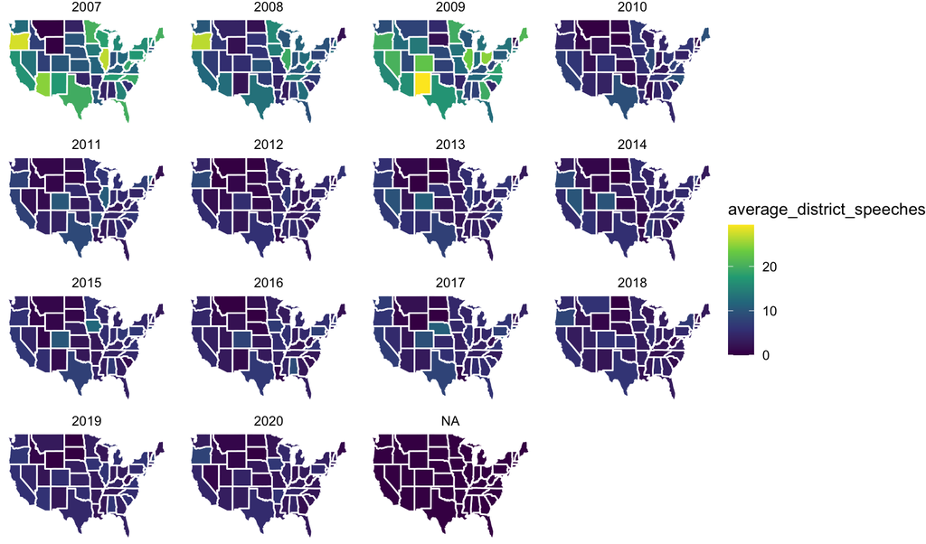

```r
# average speeches per house member
d_district %>%
  left_join(members %>% distinct(icpsr, chamber, congress, state, state_abbrev)) %>%
  filter(chamber == "House") %>%
  count(icpsr, state, year, name = "district_speeches", .drop = FALSE) %>%
  ungroup() %>%
  group_by(state, year) %>%
  summarise(average_district_speeches = mean(district_speeches, na.rm = T) %>% replace_na(0)) %>%
  ungroup() %>%
  # fill missing states with 0
  full_join(distinct(states, state)) %>%
  complete(year, state, fill = list(average_district_speeches = 0)) %>%
  # Join in lat and long
  left_join(states) %>%
  group_by(subregion) %>%
  ggplot( aes(x = long, y = lat, group = group, fill = average_district_speeches) ) +
  geom_polygon(color = "white") +
  theme_void() +
  facet_wrap("year")
```

## Sentences mentioning “district”

from the Wisconsin delegation

Excluding “district court” “their district” “their home district” “their state or district” “each/every district” “school district” etc.

```r
load(here("data", "d_district_sentences_wi.Rdata"))

# clean up strings for easier reading
d_district_sentences_wi %<>%
  mutate(district_sentences = district_sentences %>%
           str_remove("_* </pre></body></html>") %>%
           str_remove_all("\\$|`"))

to_exclude <- "district (court|attorney)|(each|every) (congressional |)district|their (congressional|home|state(s|) or|) district|school district|, districts|locality or congressional district"

# a sample of sentences from 100 speeches
d_district_sentences_wi %>%
  filter(!str_detect(district_sentences, to_exclude)) %>%
  distinct(type, subtype, district_sentences, url) %>%
  select(type, subtype, district_sentences, url) %>%
  kablebox()
```

type

subtype

district_sentences

url

legislation

BILL

Paul district offices that service wisconsin, and i do not want this bill to be misconstrued as reflecting on the work of those district offices.

https://www.congress.gov/congressional-record/2007/02/13/senate-section/article/S1903-2

legislation

AMENDMENT

Allen is a professor of ophthalmology at the university of wisconsin school of medicine in my district.

https://www.congress.gov/congressional-record/2007/12/11/house-section/article/H15261-1

legislation

ACT

The fact of the matter is, if we implement this law, if we get the president to support this cut in interest rate burden in half, over 750,000 undergraduates in my home state of wisconsin will realize cost savings, over half of them in my home congressional district alone.

https://www.congress.gov/congressional-record/2007/01/17/house-section/article/H597-1

legislation

RESOLUTION

I have had 18 military funerals in my congressional district alone, most of which i personally attended.

https://www.congress.gov/congressional-record/2007/02/14/house-section/article/H1623-4

legislation

ACT

Sadly, i have also had 18 military funerals in my congressional district alone, most of which i have personally attended.

https://www.congress.gov/congressional-record/2007/03/23/house-section/article/H2961-4

legislation

ACT

A relatively modest program with authorized funding of 33.5 million, the emp has demonstrated remarkable results in restoring river habitats all along my congressional district in western wisconsin and beyond.

https://www.congress.gov/congressional-record/2007/04/19/house-section/article/H3600-3

legislation

ACT

As a former member of the education and workforce committee over the last 10 years, i have been heavily involved in head start programs, the reauthorization process in previous congresses, and had an opportunity to visit many of the head start centers throughout my congressional district throughout western wisconsin.

https://www.congress.gov/congressional-record/2007/05/02/house-section/article/H4306-1

other

U.S. TRADE AGREEMENTS

For the first time i believe that the values of this nation are finally starting to be recognized and reflected as a basis of these trade agreements; the attempt to try to elevate standards upwards, rather than having a race to the bottom when it comes to trade relations, because so many of our constituents have felt for some time, and we have heard it in our own congressional district, that the trade agreements really don’t speak to their needs, that they are competing on an uneven playing field in relation to the rest of the world.

https://www.congress.gov/congressional-record/2007/05/22/house-section/article/H5603-1

other

U.S. TRADE AGREEMENTS

There are a lot of positive features to trade, but the congressional district i represent, western wisconsin, is still heavily manufacturing, a lot of agriculture, and there’s been a lot of displacement and a lot of jobs lost.

https://www.congress.gov/congressional-record/2007/05/22/house-section/article/H5603-1

other

HONORING THE LONG-TERM RESOURCE MONITORING PROGRAM

I am proud to have it not only in my district, but in my hometown.

https://www.congress.gov/congressional-record/2007/06/20/extensions-of-remarks-section/article/E1350-3

legislation

APPROPRIATIONS

While touring the nysp program on the uw-eau claire and uw-lacrosse campuses in my district on several occasions, i have witnessed firsthand how this program reaches beyond academics and sports to provide opportunities for learning about good nutrition, developing leadership skills and developing good character.

https://www.congress.gov/congressional-record/2007/07/18/house-section/article/H8037-2

other

AUTHORIZING ADDITIONAL FUNDS FOR EMERGENCY REPAIRS AND RECONSTRUCTION OF INTERSTATE I-35 BRIDGE IN MINNEAPOLIS, MINNESOTA

Many of the residents of my congressional district in western wisconsin make a daily commute to their jobs in the twin cities.

https://www.congress.gov/congressional-record/2007/08/03/house-section/article/H9675-2

other

EXPRESSING SYMPATHY FOR MIDWESTERN FLOOD VICTIMS

Walz here today to offer this resolution expressing our concern and support to the victims of the flooding that ravaged our congressional districts and so many other states during those fateful days in august, but also to take a moment to express our eternal gratitude and thanks to the countless numbers of official agencies, to private organizations, to individuals who rose to the call of many people in great need during this time….walz and myself, we represent two very beautiful congressional districts, but part of that beauty is the fact that we have a lot of hills and valleys and coulees that act like a funnel effect when you have the so-called 1,000-year rain’’ take place within a 24-hour period….fortunately for myself, there were none in my congressional district, but we did have some loss of life in mr….walz’s district….i was down in one of my communities in the southern part of my congressional district, gays mills, shortly after the flooding, and they described to me horrific conditions where the rain came so quickly that within a matter of an hour there was five feet of water standing on the main street in their downtown area….we also were fortunate that 20 earthen dams in vernon county in my congressional district held up.

https://www.congress.gov/congressional-record/2007/10/02/house-section/article/H11081-3

other

EXPRESSING SUPPORT FOR DESIGNATION OF A NATIONAL VETERANS HISTORY PROJECT WEEK

I call upon all members of this body to publicize and promote the veterans history project in their own districts and communities.

https://www.congress.gov/congressional-record/2007/11/05/house-section/article/H12472-1

legislation

ACT

We all here agree that we want to stop the amt from hitting 23 million more americans, 56,000 in my congressional district alone in wisconsin.

https://www.congress.gov/congressional-record/2007/11/09/house-section/article/H13417-3

legislation

ACT

In my district alone, the amt could affect 50,000 additional western wisconsin families this year, many of whom have no idea they face a tax increase.

https://www.congress.gov/congressional-record/2007/11/09/house-section/article/H13428-3

other

HEALTH CARE

Don’t think that it was opportunistic for me to tell this story, he didn’t even live in my district.

https://www.congress.gov/congressional-record/2007/02/07/house-section/article/H1329-1

other

THE ECONOMY

They include government grants for modernization, low-cost loans, debt forgiveness, tax breaks for export or businesses and subsidies for suppliers of wood and pulp, something we are keenly aware of in wisconsin, in my district, which used to be known as paper valley.

https://www.congress.gov/congressional-record/2007/03/05/house-section/article/H2149-2

legislation

ACT

By adding this critical funding to the clean water act, we will ensure the communities like those in my northeastern wisconsin district, who would otherwise be unable to upgrade their aging sewer systems, will have the necessary funding to do so.

https://www.congress.gov/congressional-record/2007/03/07/house-section/article/H2250-6

legislation

ACT

The projects funded in my district alone are indicative of the demand across the nation for this bill.

https://www.congress.gov/congressional-record/2007/03/09/house-section/article/H2351-2

other

THE ACCOUNTABILITY CONGRESS: THE 110TH CONGRESS

From my district in northeast wisconsin, 20,034 brave americans, men and women, served in both iraq and afghanistan….now, in my district that will help 64,000 veterans in northeast wisconsin alone….that will help 245 police and fire departments throughout my district….in my district alone, that helps 68,000 senior citizens, if only the senate would put that language in and if only the hhs secretary would be so kind as to use his buying group to negotiate for lower drugs.

https://www.congress.gov/congressional-record/2007/04/19/house-section/article/H3675-3

other

MAKING AMERICA LESS DEPENDENT ON FOREIGN OIL

Some of these solutions begin right on the farm, like in my own district in northeast wisconsin.

https://www.congress.gov/congressional-record/2007/05/23/house-section/article/H5628-1

other

SCHIP

During my trails across the district, i had a 15-minute conversation set aside for a native american activist.

https://www.congress.gov/congressional-record/2007/10/03/house-section/article/H11231-1

other

FISCAL RESPONSIBILITY AND THE WAR IN IRAQ

I would like to share with you now some of the words of people from my district who have concerns about money and their health and where we are going.

https://www.congress.gov/congressional-record/2007/10/10/house-section/article/H11482-1

other

FISCAL RESPONSIBILITY AND THE WAR IN IRAQ

Well, kathleen, you don’t want my coverage because i respectfully declined the health care benefits here until everyone in my district and the state and the country is offered the same cafeteria menu of choices….deb from little chute in my district.

https://www.congress.gov/congressional-record/2007/10/10/house-section/article/H11482-1

other

FISCAL RESPONSIBILITY AND THE WAR IN IRAQ

This president has failed to listen to ordinary people, people from my district who are asking for access to their doctor, who are asking him to take a new and different direction away from iraq and back after osama bin laden and his followers.

https://www.congress.gov/congressional-record/2007/10/10/house-section/article/H11482-1

other

A THANK-YOU TO OUR NATION’S TEACHERS ON NATIONAL TEACHER DAY

I want to give just one example of an extraordinary teacher from my district–the fourth district of wisconsin….payan, as well as the thousands of teachers in my district who may not have been nationally recognized, but who share that same commitment and dedication.

https://www.congress.gov/congressional-record/2007/05/08/extensions-of-remarks-section/article/E988-2

other

A TRIBUTE TO MILDRED LEIGH GOLD

Madam speaker, i rise today to recognize mildred leigh gold, a compassionate leader, a breast cancer survivor, and an advocate from the fourth congressional district….leigh gold’s dedication to women’s health care and her work to promote awareness and provide access to breast cancer treatment has truly been a life saver for many women in my district.

https://www.congress.gov/congressional-record/2007/06/05/extensions-of-remarks-section/article/E1186-5

other

TRIBUTE TO THE 440TH AIRLIFT WING BASED IN MILWAUKEE, WISCONSIN

It was formed in 1943 at baer field in indiana, but has been based at general mitchell international airport–air reserve station located in the fourth congressional district, since 1957….madam speaker, for these reasons, i am honored to pay tribute to the 440th for their stellar performance, dedication and service to my district and to the nation.

https://www.congress.gov/congressional-record/2007/06/11/extensions-of-remarks-section/article/E1244-1

legislation

BILL

4. treatment of district of columbia.–for purposes of this section– (a) the district of columbia shall be treated as a state; and (b) the district of columbia court of appeals shall act as the highest state court for the district of columbia.

https://www.congress.gov/congressional-record/2007/02/28/senate-section/article/S2357-1

legislation

AMENDMENT

4. treatment of district of columbia.–for purposes of this subsection– (i) the district of columbia shall be treated as a state; and (ii) the district of columbia court of appeals shall act as the highest state court for the district of columbia. (d) authorization of appropriations.–there are authorized to be appropriated 15,000,000 for each of the fiscal years 2008 through 2012 to carry out this section.

https://www.congress.gov/congressional-record/2007/06/04/senate-section/article/S7006-2

legislation

ACT

Joseph, michigan, is in the process of redeveloping an area of town that will link downtown with the beautiful lakefront district….joseph to create a recreational, educational, and cultural district that benefits the entire community.

https://www.congress.gov/congressional-record/2007/02/27/house-section/article/H1926-1

other

NA

Furthermore, the legislation puts seniors in my district at risk by making cuts to the medicare program.

NA

legislation

ACT

I have visited a company in my district which is engaged in very innovative and cost efficient light technology, and there are many other such efforts around the country that are developing exciting new products.

https://www.congress.gov/congressional-record/2007/08/04/house-section/article/H9722-3

legislation

AUTHORIZATION

All of us who are frequent travelers as we go back and forth to our districts know the strain that is on our air traffic system….most of us here are experienced air travelers, as we fly back and forth to our districts each week.

https://www.congress.gov/congressional-record/2007/09/20/house-section/article/H10637-2

legislation

ACT

Not since the supreme court issued its string of one person, one vote decisions in the 1960s has congress seen fit to amend the law to allow both at-large and district elections for members of the house of representatives….this bill does that and, in effect, gives the citizens of utah the right to vote for two representatives, one in the district and one at-large, which is something that is denied to every other citizen of the united states….finally, having an at-large seat in utah is going to make it probably more difficult to uphold this law, and the reason i say that is that if this law is held unconstitutional with four members from utah being elected by district, effectively a quarter of the people of utah will be disenfranchised since the bill has a nonseverability clause, and thus, if d.c. brings the bill down, one-quarter of the people of utah will have no representative in congress….i was prepared to support this legislation both in this congress and the last congress if utah had four representatives elected by districts.

https://www.congress.gov/congressional-record/2007/03/22/house-section/article/H2825-5

other

RULES OF THE HOUSE

Last year, the administration provided 18,808 fire grants in districts represented by republican members of congress….it provided 11,470 fire grants in districts represented by democrats….now, does anybody believe that that ratio of fire grants in republican versus democratic districts was not political?

https://www.congress.gov/congressional-record/2007/01/05/house-section/article/H62-2

legislation

APPROPRIATIONS

And as much as i might like to see a project like that in my district, i don’t have one, neither does the gentleman.

https://www.congress.gov/congressional-record/2007/01/31/house-section/article/H1071-3

legislation

ACT

[[Page h4778]] it is going to be very interesting to see how many of our republican friends from agricultural districts are actually going to support us in trying to provide that assistance. {time} 1315 after all, we did not declare those counties disaster areas.

https://www.congress.gov/congressional-record/2007/05/10/house-section/article/H4772-1

other

NA

The secretary of defense, notwithstanding any other provision of law, acting through the office of economic adjustment or the office of dependents education of the department of defense, shall use not less than 10,000,000 of funds made available in this title under the heading operations and maintenance, defense-wide’’ to make grants and supplement other federal funds to provide special assistance to local education agencies in districts adversely affected by significant changes in the military population….notwithstanding the notice requirement of the transportation, treasury, housing and urban development, the judiciary, the district of columbia, and independent agencies appropriations act, 2006, 119 stat….2509 (public law 109- 115), as continued in section 104 of the continuing appropriations resolution, 2007 (public law 110-5), the district of columbia courts may reallocate not more than 1,000,000 of the funds provided for fiscal year 2007 under the federal payment to the district of columbia courts for facilities among the items and entities funded under that heading for operations….section 21073 of the continuing appropriations resolution, 2007 (public law 110-5) is amended by adding a new subsection (j) as follows: (j) notwithstanding section 101, any appropriation or funds made available to the district of columbia pursuant to this division for federal payment for foster care improvement in the district of columbia’ shall be available in accordance with an expenditure plan submitted by the mayor of the district of columbia not later than 60 days after the enactment of this section which details the activities to be carried out with such federal payment.’‘….the secretary of defense, notwithstanding any other provision of law, acting through the office of economic adjustment or the office of dependents education of the department of defense, shall use not less than 10,000,000 of funds made available in this title under the heading operations and maintenance, defense-wide’’ to make grants and supplement other federal funds to provide special assistance to local education agencies in districts adversely affected by significant changes in the military population….notwithstanding the notice requirement of the transportation, treasury, housing and urban development, the judiciary, the district of columbia, and independent agencies appropriations act, 2006, 119 stat….2509 (public law 109- 115), as continued in section 104 of the continuing appropriations resolution, 2007 (public law 110-5), the district of columbia courts may reallocate not more than 1,000,000 of the funds provided for fiscal year 2007 under the federal payment to the district of columbia courts for facilities among the items and entities funded under that heading for operations….section 21073 of the continuing appropriations resolution, 2007 (public law 110-5) is amended by adding a new subsection (j) as follows: (j) notwithstanding section 101, any appropriation or funds made available to the [[page h4846]] district of columbia pursuant to this division for federal payment for foster care improvement in the district of columbia’ shall be available in accordance with an expenditure plan submitted by the mayor of the district of columbia not later than 60 days after the enactment of this section which details the activities to be carried out with such federal payment.’’.

NA

other

NA

Well, there is no spinach in my district, but let me tell you why we had that funding.

NA

legislation

APPROPRIATIONS

They suck them into the idea that we have to be atm machines for our districts, and so they focus on the tiny portion of most bills that are earmarks instead of focusing on the policy that is represented by the legislation that we produce. {time} 1815 it’s a whole lot more important to know whether we have adequately funded education or whether we have funded the right programs in education and refused to add funding to some of the worst programs in education than it is to know whether a member got a 200,000 earmark for an after-school center.

https://www.congress.gov/congressional-record/2007/06/13/house-section/article/H6347-1

legislation

APPROPRIATIONS

Now, i’ve never had anybody in my district say, why don’t you guys get your act together and cut cancer research?’’

https://www.congress.gov/congressional-record/2007/06/27/house-section/article/H7213-1

legislation

APPROPRIATIONS

But what i am bothered by is the idea that somehow we think we can come from our own communities, our own states, and then come to this town, because we happen to technically approve the district’s budget in a plantation-type style, we, therefore, begin to tell the district of columbia that we are going to decide what kind of medical advice is relevant….i am baffled by people, especially by conservatives, who every day will profess to believe in local control, states’ rights and the like, but then when it comes to the district of columbia, they say, well, because we have a special opportunity, we are going to impose our judgment on yours….but for god’s sake, it seems to me that we ought to have enough restraint to recognize that if we wanted to dictate to the d.c. what their policies ought to be, then we ought to resign from congress and run for city council for the district of columbia, or maybe even mayor….but until that time, it seems to me that the district of columbia government has the right to make their own choices even if they are wrong….you learn from your own mistakes, and if the district of columbia is making the wrong choice, then i suspect in time evidence will show they made the wrong choice.

https://www.congress.gov/congressional-record/2007/06/27/house-section/article/H7297-1

legislation

APPROPRIATIONS

If they do want their earmarks, if they do think that they have as much right as the president of the united states to determine what happens in their district, then i would suggest that they vote against the amendment.

https://www.congress.gov/congressional-record/2007/06/28/house-section/article/H7347-3

legislation

APPROPRIATIONS

States in districts with programs that were not on the department’s preferential list were either rejected for grants or pressured to change their methods, even though some argued, as did my own state, that their programs met the law’s standard.

https://www.congress.gov/congressional-record/2007/07/17/house-section/article/H7898-3

legislation

APPROPRIATIONS

But it is a whole lot easier for the press and for individual members of this house to complain about some other member, or in the case of the press any member, trying to do something in his district, or in the case of a house member complaining about somebody trying to do something in a different district.

https://www.congress.gov/congressional-record/2007/07/18/house-section/article/H8037-2

legislation

APPROPRIATIONS

So i would simply ask the question why should i serve in this body, try to help my district, and then discover that for 16 straight years we had a republican governor, i had absolutely nothing to say about funds that were distributed in my state without the earmarking process….the earmarking process, if it is used correctly, allows individual members to target things in their own district that they think will contribute the most to improving the living conditions or the educational conditions or the cultural conditions in that district.

https://www.congress.gov/congressional-record/2007/07/19/house-section/article/H8128-2

legislation

APPROPRIATIONS

The planning commission covers a 10-county area and three congressional districts, mine, the gentleman from the eighth, mr….petri’s district….but i want to ask a series of questions about the gentleman’s district.

https://www.congress.gov/congressional-record/2007/07/24/house-section/article/H8318-1

legislation

APPROPRIATIONS

I would also simply note that the median household income in the gentleman’s district is 48,000….the median household income in my own district is 39,000, a 9,000 difference….i make no apology in trying to get the median family income in my district just a mite closer to the much higher income found in the gentleman’s district.

https://www.congress.gov/congressional-record/2007/07/24/house-section/article/H8318-1

legislation

APPROPRIATIONS

So, all i can say is it is fine for someone who comes from a district as prosperous as yours to belittle or question these modest economic development efforts that are being provided around the country in districts that have a per family income of 8,000, 9,000, 10,000 less than yours.

https://www.congress.gov/congressional-record/2007/07/24/house-section/article/H8318-1

legislation

APPROPRIATIONS

But when i came to this congress, i believe there were four congressional districts in arizona, four representatives of arizona in this house, and there were 10 representatives from the state of wisconsin….now, almost 40 years later, wisconsin has eight congressional districts, eight representatives, and arizona, i believe, has a similar number.

https://www.congress.gov/congressional-record/2007/07/24/house-section/article/H8318-1

legislation

APPROPRIATIONS

As i was saying, i don’t know why one should assume that a decision to build a highway or any other project, if made by partisan bureaucrats or politically appointed bureaucrats in an agency, i don’t know why that is any more pure than a decision being made out in the open by members of congress, who i think know their districts as well as any bureaucrat….so all i would suggest is that while i am certainly not fond of the earmarking process, i am also not fond of the idea that somehow those of us from states not quite as prosperous as the gentleman’s need to be embarrassed by the fact that we are asking for a little better deal in terms of federal money spent in our districts, especially when the gentleman’s state is above the national average in terms of the amount of federal dollars spent in his own state.

https://www.congress.gov/congressional-record/2007/07/24/house-section/article/H8318-1

legislation

APPROPRIATIONS

I have to tell you there are literally thousands of jobs that have been added in my own district by corporations who were able to move into these industrial parks to get their services and grow….we have developed a very strong electronics industry in my district through the use of funds through eda.

https://www.congress.gov/congressional-record/2007/07/25/house-section/article/H8420-3

legislation

APPROPRIATIONS

2. period of application of waiver.–any waiver pursuant to paragraph (1) shall be effective for no more than a period of 6 months at a time and shall not apply beyond 12 months after the enactment of this act. (e) small business.–in entering into multiple award indefinite-quantity contracts with funds appropriated by this act, the united states agency for international development may provide an exception to the fair opportunity process for placing task orders under such contracts when the order is placed with any category of small or small disadvantaged business. (f) vietnamese refugees.–section 594(a) of the foreign operations, export financing, and related programs appropriations act, 2005 (enacted as division d of public law 108-447; 118 stat. 3038) is amended by striking and 2007’’ and inserting through 2009’‘. (g) reconstituting civilian police authority.–in providing assistance with funds appropriated by this act under section 660(b)(6) of the foreign assistance act of 1961, support for a nation emerging from instability may be deemed to mean support for regional, district, municipal, or other sub- national entity emerging from instability, as well as a nation emerging from instability. (h) china programs.–notwithstanding any other provision of law, of the funds appropriated under the heading development assistance’’ in this act, not less than 10,000,000 shall be made available to united states educational institutions and nongovernmental organizations for programs and activities in the people’s republic of china relating to the environment, democracy, and the rule of law: provided, that funds made available pursuant to this authority shall be subject to the regular notification procedures of the committees on appropriations. (i) extension of authority.– (1) with respect to funds appropriated by this act that are available for assistance for pakistan, the president may waive the prohibition on assistance contained in section 608 of this act subject to the requirements contained in section 1(b) of public law 107-57, as amended, for a determination and certification, and consultation, by the president prior to the exercise of such waiver authority….(2) the term parking fines and penalties’’ means parking fines and penalties– (a) owed to– (i) the district of columbia; or (ii) new york, new york; and (b) incurred during the period april 1, 1997, through september 30, 2007….(3) the term unpaid property taxes’’ means the amount of unpaid taxes and interest determined to be owed by a foreign country on real property in the district of columbia or new york, new york in a court order or judgment entered against such country by a court of the united states or any state or subdivision thereof. limitation on assistance for the plo for the west bank and gaza sec.

https://www.congress.gov/congressional-record/2007/12/17/house-section/article/H15528-2

legislation

APPROPRIATIONS

Those districts are entitled to representation, too, and those members are entitled to be treated with consideration, just as every other member of the house is.

https://www.congress.gov/congressional-record/2007/12/17/house-section/article/H15528-2

legislation

AMENDMENT

5. process.–any process under this paragraph may be served in any judicial district in which the electronic communication service provider may be found.

https://www.congress.gov/congressional-record/2008/01/24/senate-section/article/S288-1

other

HONORING BECKY YOUNG

Using these avenues, young was able to enact meaningful solutions to a range of issues facing the people of her district and the state of wisconsin as a whole.

https://www.congress.gov/congressional-record/2008/05/20/extensions-of-remarks-section/article/E975-3

legislation

AUTHORIZATION

I have seen the waters of the mississippi river in my own district be overrun by invasives such as the zebra mussel, which is why i have taken a keen interest in legislation to address the problem.

https://www.congress.gov/congressional-record/2008/04/25/extensions-of-remarks-section/article/E745-1

legislation

ACT

It is planting season back home in the upper midwest and the district i represent in western wisconsin, and our farmers need some predictability.

https://www.congress.gov/congressional-record/2008/04/30/house-section/article/H2924-1

legislation

ACT

But when i have producers in my district in western wisconsin coming up to me and saying, ron, why are we still receiving these direct payments when the market prices are so good right now?

https://www.congress.gov/congressional-record/2008/04/30/house-section/article/H2924-1

legislation

ACT

Back home in wisconsin, in the agriculture district that i represent, farmers for years have come up to me and said: you know, i’m not a big fan of these subsidy programs, but i just wish the market would give us a decent price so we wouldn’t have to rely on them.

https://www.congress.gov/congressional-record/2008/05/01/house-section/article/H2995-1

legislation

ACT

I still represent one of the largest agricultural producing districts in the entire nation.

https://www.congress.gov/congressional-record/2008/05/14/house-section/article/H3801-3

legislation

ACT

Speaker, as i indicated, i represent one of the largest agriculture districts in the nation, western wisconsin.

https://www.congress.gov/congressional-record/2008/05/14/house-section/article/H3801-3

legislation

ACT

In my district alone, the amt could affect 50,000 additional western wisconsin families this year, many of whom have no idea they face a tax increase.

https://www.congress.gov/congressional-record/2008/06/25/house-section/article/H6031-1

other

THE STATE OF THE ECONOMY

The unemployment rate up to 5 percent nationwide; some areas of my district even more….that’s 320 homes in a very small neighborhood that won’t have a bread earner, in kimberly, wisconsin, just outside of my district, 120 paper making jobs.

https://www.congress.gov/congressional-record/2008/01/16/house-section/article/H276-1

other

THE STATE OF THE ECONOMY

I think what people in wisconsin are telling me in green bay and clintonville, everywhere i go throughout my district, is they want their country back.

https://www.congress.gov/congressional-record/2008/01/16/house-section/article/H276-1

other

HEALTH CARE

The greatest expense everywhere in wisconsin, as i went around the district to listen to different employers, whether you’re in agriculture and a family farmer or a small businessman trying to run a photography shop, the greatest expense in their overhead is their health care cost….speaker, i would like to share with you some words i was privileged to listen to in a small town in the northern part of wisconsin, a district i have the honor and privilege of representing.

https://www.congress.gov/congressional-record/2008/02/14/house-section/article/H974-2

legislation

BUDGET

But what’s happening today in households across my district is people are running faster to stand still.

https://www.congress.gov/congressional-record/2008/03/12/house-section/article/H1612-1

other

DEMOCRATS WORKING TO SOLVE AMERICA’S PROBLEMS

Not the boats in my district, but median income might be 28,000 to 32,000 a year.

https://www.congress.gov/congressional-record/2008/05/14/house-section/article/H3870-1

other

GETTING BACK TO THE BASICS

Rural areas, like the district i represent in northeast wisconsin, are affected most.

https://www.congress.gov/congressional-record/2008/07/10/house-section/article/H6346-6

other

HONORING FIRE CHIEF FRANK WICHLACZ

Well, yesterday in my district in northeast wisconsin, the pulaski community began to mourn the tragic death of fire chief frank wichlacz, a volunteer firefighter who died in a freak accident on wednesday….on behalf of the people of the eighth district in northeast wisconsin, allow me to express my deepest sympathy to his family and friends and to all in the pulaski community.

https://www.congress.gov/congressional-record/2008/07/24/house-section/article/H7138-3

other

REAFFIRMING SUPPORT FOR THE GOVERNMENT OF LEBANON UNDER PRIME MINISTER FOUAD SINIORA

Heated last-minute negotiations over how to reshape lebanon’s electoral districting system which will significantly influence power-sharing after the 2009 parliamentary elections led to a compromise that divides the country into smaller districts, allowing for more equal representation of its various sects.

https://www.congress.gov/congressional-record/2008/06/03/extensions-of-remarks-section/article/E1111-4

other

HONORING ARMY SPECIALIST STEVEN CHRISTOFFERSON

Madam speaker, in april, over 350 friends, family members, and others in the community inspired by the life of army specialist steven christofferson gathered at the cudahy high school field house in my district to pay their respects to [[page e1516]] this remarkable young man whose life was cut tragically short in iraq last month.

https://www.congress.gov/congressional-record/2008/07/22/extensions-of-remarks-section/article/E1515-4

legislation

ACT

It’s about watching out for workers, families, retirees and small businesses in my district who will be up against the wall by this resulting credit crisis as it spreads to main street….we are already beginning to see the effects in my district and across the country.

https://www.congress.gov/congressional-record/2008/11/19/extensions-of-remarks-section/article/E2259-4

legislation

ACT

I am introducing this bill in response to comments i have heard from independent truckers and small trucking companies in my district and the state of wisconsin.

https://www.congress.gov/congressional-record/2008/04/30/extensions-of-remarks-section/article/E777-2

legislation

ACT

I am assuming they did that because an overwhelming number of honorable members on both sides of the aisle believe that members should not lose the ability to fund priority items for their districts because of the scurrilous behavior of a handful of renegade members.

https://www.congress.gov/congressional-record/2008/02/07/house-section/article/H628-3

legislation

APPROPRIATIONS

War profiteering and fraud (a) prohibition.–whoever, in any matter involving a contract with, or the provision of goods or services to, the united states or a provisional authority, in connection with a mission of the united states government overseas, knowingly– (1)(a) executes or attempts to execute a scheme or artifice to defraud the united states or that authority; or (b) materially overvalues any good or service with the intent to defraud the united states or that authority; shall be fined not more than 1,000,000 or imprisoned not more than 20 years, or both; or (2) in connection with the contract or the provision of those goods or services– (a) falsifies, conceals, or covers up by any trick, scheme, or device a material fact; (b) makes any materially false, fictitious, or fraudulent statements or representations; or (c) makes or uses any materially false writing or document knowing the same to contain any materially false, fictitious, or fraudulent statement or entry; shall be fined not more than 1,000,000 or imprisoned not more than 10 years, or both. (b) extraterritorial jurisdiction.–there is extraterritorial federal jurisdiction over an offense under this section. (c) venue.–a prosecution for an offense under this section may be brought– (1) as authorized by chapter 211 of this title; (2) in any district where any act in furtherance of the offense took place; or (3) in any district where any party to the contract or provider of goods or services is located.’’….(2) independent comprehensive study and report.– (a) in general.–not later than july 1, 2008, the secretary of health and human services shall enter into a contract with an independent organization for the purpose of– (i) producing a comprehensive report on the prevalence of the problems outlined in the report submitted under paragraph (1); (ii) identifying strategies in existence to address these problems; and (iii) assessing the impact of each regulation referred to in such paragraph on each state and the district of columbia….(d) cooperation of states.–if the secretary of health and human services determines that a state or the district of columbia has not cooperated with the independent organization for purposes of the report under this paragraph, the secretary shall reduce the amount paid to the state or district under section 1903(a) of the social security act (42 u.s.c. 1396b(a)) by 25,000 for each day on which the secretary determines such state or district has not so cooperated….such reduction shall be made through a process that permits the state or district to challenge the secretary’s determination….(4) exemption of territories.–this section shall only apply to the 50 states and the district of columbia. (b) asset verification program.– (1) in general.–for purposes of this section, an asset verification program means a program described in paragraph (2) under which a state– (a) requires each applicant for, or recipient of, medical assistance under the state plan under this title on the basis of being aged, blind, or disabled to provide authorization by such applicant or recipient (and any other person whose resources are material to the determination of the eligibility of the applicant or recipient for such assistance) for the state to obtain (subject to the cost reimbursement requirements of section 1115(a) of the right to financial privacy act but at no cost to the applicant or recipient) from any financial institution (within the meaning of section 1101(1) of such act) any financial record (within the meaning of section 1101(2) of such act) held by the institution with respect to the applicant or recipient (and such other person, as applicable), whenever the state determines the record is needed in connection with a determination with respect to such eligibility for (or the amount or extent of) such medical assistance; and (b) uses the authorization provided under subparagraph (a) to verify the financial resources of such applicant or recipient (and such other person, as applicable), in order to determine or redetermine the eligibility of such applicant or recipient for medical assistance under the state plan.

https://www.congress.gov/congressional-record/2008/05/15/house-section/article/H3905-3

legislation

APPROPRIATIONS

Chapter 3 department of defense–civil department of the army corps of engineers–civil construction for an additional amount for construction’’ for necessary expenses related to the consequences of hurricane katrina and other hurricanes of the 2005 season, and for recovery from other natural disasters 5,033,345,000, to remain available until expended: provided, that the secretary of the army is directed to use 4,362,000,000 of the funds appropriated under this heading to modify authorized projects in southeast louisiana to provide hurricane and storm damage reduction and flood damage reduction in the greater new orleans and surrounding areas to provide the levels of protection necessary to achieve the certification required for participation in the national flood insurance program under the base flood elevations current at the time of this construction; 1,657,000,000 shall be used for the lake pontchartrain and vicinity; 1,415,000,000 shall be used for the west bank and vicinity project; and 1,290,000,000 shall be for elements of the southeast louisiana urban drainage project, that are within the geographic perimeter of the west bank and vicinity and lake pontchartrain and vicinity projects to provide for interior drainage of runoff from rainfall with a 10 percent annual exceedance probability: provided further, that none of this 4,362,000,000 shall become available for obligation until october 1, 2008: provided further, that non-federal cost allocations for these projects shall be consistent with the cost-sharing provisions under which the projects were originally constructed: provided further, that the 1,315,000,000 non-federal cost share for these projects shall be repaid in accordance with provisions of section 103(k) of public law 99-662 over a period of 30 years: provided further, that the expenditure of funds as provided above may be made without regard to individual amounts or purposes except that any reallocation of funds that are necessary to accomplish the established goals are authorized, subject to the approval of the house and senate committees on appropriations: provided further, that the secretary of the army is directed to use 604,745,000 of the funds appropriated under this heading to provide hurricane and storm damage reduction, flood damage reduction and ecosystem restoration along the gulf coast of mississippi and surrounding areas generally as described in the mobile district engineer’s mississippi coastal improvements program comprehensive plan report; 173,615,000 shall be used for ecosystem restoration projects; 4,550,000 shall be used for the moss point municipal relocation project; 5,000,000 shall be used for the waveland floodproofing project; 150,000 shall be used for the mississippi sound sub aquatic vegetation project; 15,430,000 shall be used for the coast-wide dune restoration project; 397,000,000 shall be used for the homeowners assistance and relocation project; and 9,000,000 shall be used for the forrest heights hurricane and storm damage reduction project: provided further, that none of this 604,745,000 shall become available for obligation until october 1, 2008: provided further, that these projects shall be initiated only after non-federal interests have entered into binding agreements with the secretary requiring the non-federal interests to pay 100 percent of the operation, maintenance, repair, replacement, and rehabilitation costs of the project and to hold and save the united states free from damages due to the construction or operation and maintenance of the project, except for damages due to the fault or negligence of the united states or its contractors: provided further, that the 211,661,000 non-federal cost share for these projects shall be repaid in accordance with the provisions of section 103(k) of public law 99-662 over a period of 30 years: provided further, that the expenditure of funds as provided above may be made without regard to individual amounts or purposes except that any reallocation of funds that are necessary to accomplish the established goals are authorized, subject to the approval of the house and senate committees on appropriations: provided further, that the secretary of the army is directed to use 66,600,000 of the funds appropriated under this heading to address emergency situations at corps of engineers projects and rehabilitate and repair damages to corps projects caused by recent natural disasters: provided further, that the chief of engineers, acting through the assistant secretary of the army for civil works, shall provide a monthly report to the house and senate committees on appropriations detailing the allocation and obligation of these funds, beginning not later than 60 days after enactment of this act….until such time as the updating of flood insurance rate maps under section 19 of the flood modernization act of 2007 is completed (as determined by the district engineer) for all areas located in the st….louis district of the mississippi valley division of the corps of engineers, the administrator of the federal emergency management agency shall not adjust the chargeable premium rate for flood insurance under this section for any type or class of property located in an area in that district nor require the purchase of flood insurance for any type or class of property located in an area in that district not subject to such purchase requirement prior to the updating of such national flood insurance program rate map: provided, that for purposes of this section, the term area’’ does not include any area (or subdivision thereof) that has chosen not to participate in the flood insurance program under this section as of the date of enactment of this act….(4) exemption of territories.–this section shall only apply to the 50 states and the district of columbia. (b) asset verification program.– (1) in general.–for purposes of this section, an asset verification program means a program described in paragraph (2) under which a state– (a) requires each applicant for, or recipient of, medical assistance under the state plan under this title on the basis of being aged, blind, or disabled to provide authorization by such applicant or recipient (and any other person whose resources are required by law to be disclosed to determine the eligibility of the applicant or recipient for such assistance) for the state to obtain (subject to the cost reimbursement requirements of section 1115(a) of the right to financial privacy act of 1978 but at no cost to the applicant or recipient) from any financial institution (within the meaning of section 1101(1) of such act) any financial record (within the meaning of section 1101(2) of such act) held by the institution with respect to the applicant or recipient (and such other person, as applicable), whenever the state determines the record is needed in connection with a determination with respect to such eligibility for (or the amount or extent of) such medical assistance; and (b) uses the authorization provided under subparagraph (a) to verify the financial resources of such applicant or recipient (and such other person, as applicable), in order to determine or redetermine the eligibility of such applicant or recipient for medical assistance under the state plan.

https://www.congress.gov/congressional-record/2008/06/19/house-section/article/H5622-2

legislation

APPROPRIATIONS

We also believe that any individual member who happens to have a project in his district which is going to be challenged by another member, that that member has the right to notice of that challenge.

https://www.congress.gov/congressional-record/2008/07/31/house-section/article/H7649-1

legislation

ACT

The first fight i ever had on this floor was when bob giaimo and i pried loose the money for the district subway when the appropriations committee was trying to dictate local transportation policy….most members of this congress would fight to preserve local authority for their own communities, but they don’t hesitate to destroy it when the district of columbia’s around….if i’m expected to vote on their issues, i want to know where is my check from the district government?…if members of this body want to decide d.c. policy instead of running for the congress, they ought to run for the district council, and they ought to cut their paychecks to the district council level.

https://www.congress.gov/congressional-record/2008/09/16/house-section/article/H8168-1

legislation

ACT

If you want some special project for your state or district, the authorizing committee of jurisdiction should review it, and legislation authorizing it should pass both houses and be signed into law.

https://www.congress.gov/congressional-record/2009/02/04/senate-section/article/S1474-2

other

ZIMBABWE

According to human rights watch, the police and army continue to use brutal force to control access to the diamond fields of marange district in eastern zimbabwe.

https://www.congress.gov/congressional-record/2009/10/05/senate-section/article/S10106-2

other

COMPREHENSIVE HEALTH CARE REFORM

We all travel back and forth between washington, d.c., and our home districts….i represent an extraordinary constituency in south central wisconsin, and there is nowhere i travel in my district that i don’t hear these stories that tug on your heartstrings and tell us in no uncertain terms that we must take action, and we must take action in this session of congress….michael in poynette, wisconsin, in my district says, i am a [federal employee] and a member of the wisconsin wi air national guard.

https://www.congress.gov/congressional-record/2009/02/12/house-section/article/H1289-1

other

THE 30-SOMETHING WORKING GROUP: HEALTH CARE

I represent a district in south central wisconsin.

https://www.congress.gov/congressional-record/2009/06/09/house-section/article/H6387-6

other

RECOGNIZING 40TH ANNIVERSARY OF NATIONAL EYE INSTITUTE

Speaker, i want to close by recognizing just a few of the champions of eye health and the warriors against eye disease from the district that i have the privilege of representing….and i know, like my coauthor, congressman sessions, we were drawn to this issue because of pioneering things that are happening in each of our respective districts….also, a technology called brainport is being developed in my district by a company called wicab with the support of national eye institute funding, and this technology is helping the blind to find new ways to process visual information.

https://www.congress.gov/congressional-record/2009/06/16/house-section/article/H6843-1

other

RECOGNIZING TERESA MORA FOR HER SERVICE TO THE FIRST DISTRICT OF WISCONSIN

Teresa is the field representative in my district office and has worked with me for more than ten years….her unique experience has given her a great love for her adopted country combined with passion to help others of hispanic background who make up a considerable part of wisconsin’s first congressional district….i am proud to acknowledge the excellent service and positive efforts teresa mora has made over ten years to make life better for the families of wisconsin’s first congressional district.

https://www.congress.gov/congressional-record/2009/10/13/extensions-of-remarks-section/article/E2512-2

other

RECOGNIZING CHAD ALLEN HERBERT FOR HIS SERVICE TO THE FIRST DISTRICT OF WISCONSIN

Madam speaker, i rise to honor chad allen herbert, who is the constituent services representative for military issues in my district office….chad is the big brother’’ of our district office staff….as a result, he has done more over the years to help men and women of the first congressional district who serve in the armed services than anyone i know of….i am privileged to recognize his ten years of service in my office to the military families of wisconsin’s first district.

https://www.congress.gov/congressional-record/2009/10/13/extensions-of-remarks-section/article/E2513-1

other

RECOGNIZING DANYELL TREMMEL FOR HER SERVICE TO THE FIRST DISTRICT OF WISCONSIN

Madam speaker, i rise to honor miss danyell tremmel, our district director, for more than 10 years of work in the first congressional district of wisconsin office serving my constituents….danyell has actually been working for the people of the district even longer than i have….when mark neumann represented the district in the house of representatives, she was his only caseworker….danyell directs my district office operations whenever the chief of staff is unavailable, and will be doing so for an extended time while he serves his country on military duty in iraq….danyell has kept her enthusiasm, high standards, and work ethic as she has worked with me for the people of the first district.

https://www.congress.gov/congressional-record/2009/10/13/extensions-of-remarks-section/article/E2513-4

other

RECOGNIZING JOYCE YAMAT MEYER FOR HER SERVICE TO THE FIRST DISTRICT OF WISCONSIN

Joyce is one of my partners in serving the people of wisconsin’s first congressional district….following state redistricting in 2002, she was thrilled to find that her home was now in the first district….i am pleased to recognize joyce yamat meyer for more than ten years of excellent work with me in serving the people of the first district.

https://www.congress.gov/congressional-record/2009/10/13/extensions-of-remarks-section/article/E2514-2

other

A CLEAN ENERGY FUTURE

Just today, i had the owner of a company in manitowoc, wisconsin–i represent a district in wisconsin–called orion energy, which has developed what is called the apollo light tube.

https://www.congress.gov/congressional-record/2009/03/25/house-section/article/H4004-4

other

COMMEMORATING EARTH DAY

These are just two ways people in my district and my state are doing their part.

https://www.congress.gov/congressional-record/2009/04/22/extensions-of-remarks-section/article/E944-1

legislation

ACT

The federal government helped subsidize the hydro and nuclear plants in other parts of the country; ratepayers in my district should not have to send more money their way while we seek to realize the same low-carbon generation….it will provide an unprecedented investment in the technologies and industries of tomorrow, creating more than 4,000 jobs in my congressional district alone, and millions nationwide….finally, the bill includes opportunities for farmers, ranchers, and foresters to be a part of the climate solution, which is critical for my district, where agriculture remains the largest industry.

https://www.congress.gov/congressional-record/2009/06/26/house-section/article/H7471-1

other

HONORING THE 100TH ANNIVERSARY OF THE UNIVERSITY OF WISCONSIN-LA CROSSE

All of the six universities located in the congressional district have superior technology, science and math programs that will place graduates in the innovative industries in the future….currently, i have seven graduates from uw-la crosse on my staff, who happen to be with us today in the house gallery, from my chief of staff, erik olson, to my district office manager, loren kannenberg, shannon glynn, steve sipe, brad smith, karrie jackelen and mark seitz….i congratulate them on their achievement and thank them for the outstanding work they do on behalf of the people of the third congressional district of western wisconsin.

https://www.congress.gov/congressional-record/2009/10/13/house-section/article/H11187-1

legislation

ACT

I know, in my district in western wisconsin, i haven’t been on the phone more often than in the past year talking to small business owners who are struggling to get credit in order to keep their doors open….in my region of the world, in my district, i know, unless small businesses have the ability to keep their doors open–to make payroll, to make investments, and to expand jobs–we’re not going to see the type of job growth that is required to recover from the worst economic recession since the great depression.

https://www.congress.gov/congressional-record/2009/10/29/house-section/article/H12069-3

other

H. RES. 866, VETERANS HISTORY PROJECT

I call upon all members of this body to publicize and promote the veterans history project in their own districts and communities.

https://www.congress.gov/congressional-record/2009/11/17/extensions-of-remarks-section/article/E2787-4

legislation

ACT

Other provisions important to my district in western wisconsin include the conservation easement credit, which gives individuals an incentive to protect environmentally important [[page h14405]] land in perpetuity, and the extension of a 5-year depreciation period for farm and agricultural equipment….following devastating floods in my district in 2007 and 2008, it became clear to me that more tools were needed to assist individuals and businesses to recover.

https://www.congress.gov/congressional-record/2009/12/09/house-section/article/H14385-3

other

HEALTH CARE FOR AMERICA

I think people in our districts understand the situation just as well as we do here in congress, and we are working very hard to bring about the changes that we need.

https://www.congress.gov/congressional-record/2009/04/28/house-section/article/H4898-16

other

HEALTH CARE FOR AMERICA

People in my district are telling me, kagen, health care costs are just impossible.

https://www.congress.gov/congressional-record/2009/04/28/house-section/article/H4898-16

other

HEALTH CARE IN AMERICA

Now, recently, i received a mailing from an insurance company that is in my district.

https://www.congress.gov/congressional-record/2009/06/03/house-section/article/H6138-2

(Excluding district (court|attorney)|(each|every) (congressional |)district|their (congressional|home|state(s|) or|) district|school district|, districts|locality or congressional district)

### Sentences mentioning “my district”

Also including my/our district, my/our congressional district/ my/our community/communities, my/our home district etc.

```r
to_include <- "(my|our) district|(my|our) congressional district|(my|our) communit|(my/our) home district|i represent a district|(my/our) constituent"

# a sample of sentences from 100 speeches
d_district_sentences_wi %>%
  filter(str_detect(district_sentences, to_include)) %>%
  distinct(type, subtype, district_sentences, url) %>%
  select(type, subtype, district_sentences, url) %>%
  kablebox()
```

| type | subtype | district_sentences | url |
| --- | --- | --- | --- |
| other | COVER THE UNINSURED WEEK | The lack of affordable, comprehensive health care affects every congressional district in this nation….i represent a district in south central wisconsin, and while the letters i read may be from the s… | https://www.congress.gov/congressional-record/2007/04/24/house-section/article/H4046-1 |
| legislation | AMENDMENT | Allen is a professor of ophthalmology at the university of wisconsin school of medicine in my district. | https://www.congress.gov/congressional-record/2007/12/11/house-section/article/H15261-1 |
| legislation | RESOLUTION | I have had 18 military funerals in my congressional district alone, most of which i personally attended. | https://www.congress.gov/congressional-record/2007/02/14/house-section/article/H1623-4 |
| legislation | ACT | Sadly, i have also had 18 military funerals in my congressional district alone, most of which i have personally attended. | https://www.congress.gov/congressional-record/2007/03/23/house-section/article/H2961-4 |
| legislation | ACT | A relatively modest program with authorized funding of 33.5 million, the emp has demonstrated remarkable results in restoring river habitats all along my congressional district in western wisconsin an… | https://www.congress.gov/congressional-record/2007/04/19/house-section/article/H3600-3 |
| legislation | ACT | As a former member of the education and workforce committee over the last 10 years, i have been heavily involved in head start programs, the reauthorization process in previous congresses, and had an … | https://www.congress.gov/congressional-record/2007/05/02/house-section/article/H4306-1 |
| other | HONORING THE LONG-TERM RESOURCE MONITORING PROGRAM | I am proud to have it not only in my district, but in my hometown. | https://www.congress.gov/congressional-record/2007/06/20/extensions-of-remarks-section/article/E1350-3 |
| legislation | APPROPRIATIONS | While touring the nysp program on the uw-eau claire and uw-lacrosse campuses in my district on several occasions, i have witnessed firsthand how this program reaches beyond academics and sports to pro… | https://www.congress.gov/congressional-record/2007/07/18/house-section/article/H8037-2 |
| other | AUTHORIZING ADDITIONAL FUNDS FOR EMERGENCY REPAIRS AND RECONSTRUCTION OF INTERSTATE I-35 BRIDGE IN MINNEAPOLIS, MINNESOTA | Many of the residents of my congressional district in western wisconsin make a daily commute to their jobs in the twin cities. | https://www.congress.gov/congressional-record/2007/08/03/house-section/article/H9675-2 |
| other | EXPRESSING SYMPATHY FOR MIDWESTERN FLOOD VICTIMS | Walz here today to offer this resolution expressing our concern and support to the victims of the flooding that ravaged our congressional districts and so many other states during those fateful days i… | https://www.congress.gov/congressional-record/2007/10/02/house-section/article/H11081-3 |
| legislation | ACT | We all here agree that we want to stop the amt from hitting 23 million more americans, 56,000 in my congressional district alone in wisconsin. | https://www.congress.gov/congressional-record/2007/11/09/house-section/article/H13417-3 |
| legislation | ACT | In my district alone, the amt could affect 50,000 additional western wisconsin families this year, many of whom have no idea they face a tax increase. | https://www.congress.gov/congressional-record/2007/11/09/house-section/article/H13428-3 |
| other | HEALTH CARE | Don’t think that it was opportunistic for me to tell this story, he didn’t even live in my district. | https://www.congress.gov/congressional-record/2007/02/07/house-section/article/H1329-1 |
| other | THE ECONOMY | They include government grants for modernization, low-cost loans, debt forgiveness, tax breaks for export or businesses and subsidies for suppliers of wood and pulp, something we are keenly aware of i… | https://www.congress.gov/congressional-record/2007/03/05/house-section/article/H2149-2 |
| legislation | ACT | The projects funded in my district alone are indicative of the demand across the nation for this bill. | https://www.congress.gov/congressional-record/2007/03/09/house-section/article/H2351-2 |
| other | THE ACCOUNTABILITY CONGRESS: THE 110TH CONGRESS | From my district in northeast wisconsin, 20,034 brave americans, men and women, served in both iraq and afghanistan….now, in my district that will help 64,000 veterans in northeast wisconsin alone….th… | https://www.congress.gov/congressional-record/2007/04/19/house-section/article/H3675-3 |
| other | FISCAL RESPONSIBILITY AND THE WAR IN IRAQ | I would like to share with you now some of the words of people from my district who have concerns about money and their health and where we are going. | https://www.congress.gov/congressional-record/2007/10/10/house-section/article/H11482-1 |
| other | FISCAL RESPONSIBILITY AND THE WAR IN IRAQ | Well, kathleen, you don’t want my coverage because i respectfully declined the health care benefits here until everyone in my district and the state and the country is offered the same cafeteria menu … | https://www.congress.gov/congressional-record/2007/10/10/house-section/article/H11482-1 |
| other | FISCAL RESPONSIBILITY AND THE WAR IN IRAQ | This president has failed to listen to ordinary people, people from my district who are asking for access to their doctor, who are asking him to take a new and different direction away from iraq and b… | https://www.congress.gov/congressional-record/2007/10/10/house-section/article/H11482-1 |
| other | A THANK-YOU TO OUR NATION’S TEACHERS ON NATIONAL TEACHER DAY | I want to give just one example of an extraordinary teacher from my district–the fourth district of wisconsin….payan, as well as the thousands of teachers in my district who may not have been national… | https://www.congress.gov/congressional-record/2007/05/08/extensions-of-remarks-section/article/E988-2 |
| other | A TRIBUTE TO MILDRED LEIGH GOLD | Madam speaker, i rise today to recognize mildred leigh gold, a compassionate leader, a breast cancer survivor, and an advocate from the fourth congressional district….leigh gold’s dedication to women’… | https://www.congress.gov/congressional-record/2007/06/05/extensions-of-remarks-section/article/E1186-5 |
| other | TRIBUTE TO THE 440TH AIRLIFT WING BASED IN MILWAUKEE, WISCONSIN | It was formed in 1943 at baer field in indiana, but has been based at general mitchell international airport–air reserve station located in the fourth congressional district, since 1957….madam speaker… | https://www.congress.gov/congressional-record/2007/06/11/extensions-of-remarks-section/article/E1244-1 |
| other | NA | Furthermore, the legislation puts seniors in my district at risk by making cuts to the medicare program. | NA |
| legislation | ACT | I have visited a company in my district which is engaged in very innovative and cost efficient light technology, and there are many other such efforts around the country that are developing exciting n… | https://www.congress.gov/congressional-record/2007/08/04/house-section/article/H9722-3 |
| legislation | AUTHORIZATION | All of us who are frequent travelers as we go back and forth to our districts know the strain that is on our air traffic system….most of us here are experienced air travelers, as we fly back and forth… | https://www.congress.gov/congressional-record/2007/09/20/house-section/article/H10637-2 |
| legislation | ACT | In my district, nearly a third of school districts currently use their own funds to participate in adaptive testing in addition to the state assessment required by nclb….i believe that school district… | https://www.congress.gov/congressional-record/2007/10/25/extensions-of-remarks-section/article/E2252-2 |
| legislation | APPROPRIATIONS | And as much as i might like to see a project like that in my district, i don’t have one, neither does the gentleman. | https://www.congress.gov/congressional-record/2007/01/31/house-section/article/H1071-3 |
| other | NA | Well, there is no spinach in my district, but let me tell you why we had that funding. | NA |
| legislation | APPROPRIATIONS | They suck them into the idea that we have to be atm machines for our districts, and so they focus on the tiny portion of most bills that are earmarks instead of focusing on the policy that is represen… | https://www.congress.gov/congressional-record/2007/06/13/house-section/article/H6347-1 |
| legislation | APPROPRIATIONS | Now, i’ve never had anybody in my district say, why don’t you guys get your act together and cut cancer research?’’ | https://www.congress.gov/congressional-record/2007/06/27/house-section/article/H7213-1 |

[output cut: 70 more lines]

(Including only (my|our) district|(my|our) congressional district|(my|our) communit|(my/our) home district|i represent a district|(my/our) constituent)

> TODO: (1) Refine this to exclude non-district-referenceing language and (2) include other district-referencing language